# Filtering Spam Emails via Classification Tree-Based Models

Andy Nguyen, Michael Wolfe, Joseph Caguioa

6/10/2020

## Objective

Most spam messages can usually be identified in a person’s email list through the subject line and sender, but may occassionally require a glimpse of the message contents to provide a more conclusive approach. Spam filters examine these various characteristics of an email before classifying the message and placing it into the inbox of spam folder.

In this study, a classification tree-based model will be built to predict whether an email message is spam (unwanted) or not spam (wanted) through recursive partitioning.

## Data Description

The model will be built using data from the open-source [Apache SpamAssassin Project](https://spamassassin.apache.org/) that contains over 9000 labeled email messages for the purposes of developing spam filters. The original data from the SpamAssassin corpus is in text format and must be processed to quantify the information into a useful format.

[output not shown]

An email can be separated into the header and the body. The header contains information regarding the date sent, the sender, the subject, the message ID, carbon copy recipients, and additional routing information. This can be understood as the encasing envelope for the message. The body can understood as the actual letter that contains the intended message for the recipient and may contain additional information beyond text such as file attachments.

Table 1: First 10 Process Emails

| isSpam | isRe | underscore | priority | isInReplyTo | sortedRec | subPunc | multipartText | hasImages | isPGPsigned | subSpamWords | noHost | numEnd | isYelling | isOrigMsg | isDear | isWrote | numLines | bodyCharCt | subExcCt | subQuesCt | numAtt | numRec | perCaps | hour | perHTML | subBlanks | forwards | avgWordLen | numDlr |
| --- | --- | --- | --- | --- | --- | --- | --- | --- | --- | --- | --- | --- | --- | --- | --- | --- | --- | --- | --- | --- | --- | --- | --- | --- | --- | --- | --- | --- | --- |
| F | T | F | F | T | T | F | F | F | F | F | F | F | F | F | F | F | 50 | 1554 | 0 | 0 | 0 | 2 | 4.451039 | 11 | 0 | 12.50000 | 0.000000 | 4.376623 | 3 |
| F | F | F | F | F | T | F | F | F | F | F | F | F | F | F | F | F | 26 | 873 | 0 | 0 | 0 | 1 | 7.491289 | 11 | 0 | 8.00000 | 0.000000 | 4.555556 | 0 |
| F | F | F | F | F | T | F | F | F | F | F | F | F | F | F | F | F | 38 | 1713 | 0 | 0 | 0 | 1 | 7.436096 | 12 | 0 | 8.00000 | 0.000000 | 4.817164 | 0 |
| F | F | F | F | F | T | F | F | F | F | F | F | F | F | F | F | F | 32 | 1095 | 0 | 0 | 0 | 0 | 5.090909 | 13 | 0 | 18.91892 | 3.125000 | 4.714286 | 0 |
| F | T | F | F | F | T | F | F | F | F | F | F | F | F | F | F | F | 31 | 1021 | 0 | 0 | 0 | 1 | 6.116643 | 13 | 0 | 15.21739 | 6.451613 | 4.234940 | 0 |
| F | T | F | F | T | T | F | F | F | F | F | F | F | F | F | F | F | 25 | 718 | 0 | 0 | 0 | 1 | 7.625272 | 13 | 0 | 15.21739 | 12.000000 | 3.956897 | 0 |
| F | F | F | F | F | T | F | F | F | F | F | F | F | F | F | F | F | 38 | 1288 | 0 | 0 | 0 | 1 | 6.343714 | 13 | 0 | 17.02128 | 0.000000 | 4.051402 | 0 |
| F | T | F | F | F | T | F | F | F | F | F | F | F | F | F | F | T | 39 | 1182 | 0 | 0 | 0 | 1 | 6.617647 | 14 | 0 | 15.21739 | 12.820513 | 4.039604 | 0 |
| F | F | F | F | F | T | F | F | F | F | F | F | F | F | F | F | F | 126 | 5989 | 0 | 0 | 0 | 1 | 3.161361 | 14 | 0 | 6.25000 | 0.000000 | 4.405222 | 0 |
| F | F | F | F | F | T | F | F | F | F | F | F | F | F | F | F | F | 19 | 848 | 0 | 0 | 0 | 1 | 5.564648 | 14 | 0 | 11.11111 | 0.000000 | 4.849206 | 0 |

Table 2: Last 10 Processed Emails

|  | isSpam | isRe | underscore | priority | isInReplyTo | sortedRec | subPunc | multipartText | hasImages | isPGPsigned | subSpamWords | noHost | numEnd | isYelling | isOrigMsg | isDear | isWrote | numLines | bodyCharCt | subExcCt | subQuesCt | numAtt | numRec | perCaps | hour | perHTML | subBlanks | forwards | avgWordLen | … |
| --- | --- | --- | --- | --- | --- | --- | --- | --- | --- | --- | --- | --- | --- | --- | --- | --- | --- | --- | --- | --- | --- | --- | --- | --- | --- | --- | --- | --- | --- | --- |
| 6191 | T | F | F | F | F | T | F | F | F | F | F | F | T | F | F | F | F | 196 | 10810 | 0 | 0 | 0 | 1 | 4.622030 | 18 | 83.95592 | 14.285714 | 0.0000000 | 4.367924 | … |
| 6192 | T | F | F | F | F | T | F | F | F | F | F | F | F | F | F | F | F | 72 | 3388 | 1 | 0 | 0 | 1 | 48.856624 | 12 | 0.00000 | 10.000000 | 0.0000000 | 7.046036 | … |
| 6193 | T | F | F | F | F | T | F | F | F | F | F | F | F | F | F | F | F | 123 | 4258 | 0 | 0 | 0 | 1 | 18.228974 | 16 | 60.00517 | 12.903226 | 0.0000000 | 4.290938 | … |
| 6194 | T | F | F | F | F | F | F | F | F | F | F | F | T | F | F | F | F | 121 | 5945 | 0 | 0 | 0 | 1 | 25.321543 | 19 | 37.32338 | 3.719008 | 0.8264463 | 4.151279 | … |
| 6195 | T | F | F | F | F | T | F | F | F | F | T | F | T | F | F | F | F | 15 | 461 | 0 | 0 | 0 | 1 | 2.868853 | 21 | 0.00000 | 14.285714 | 0.0000000 | 4.692308 | … |
| 6196 | T | F | F | F | F | T | F | F | F | F | F | F | F | F | F | F | F | 245 | 14841 | 1 | 1 | 0 | 1 | 8.572552 | 21 | 79.65711 | 13.793103 | 0.0000000 | 4.700554 | … |
| 6197 | T | F | F | F | F | T | F | T | F | F | F | F | F | F | F | F | F | 58 | 1288 | 0 | 0 | 1 | 1 | 9.436009 | 23 | 0.00000 | 10.526316 | 0.0000000 | 4.904255 | … |
| 6198 | T | F | F | F | F | F | F | F | F | F | T | F | F | F | F | F | F | 53 | 2420 | 0 | 0 | 0 | 1 | 2.418448 | 8 | 0.00000 | 20.000000 | 0.0000000 | 4.703704 | … |
| 6199 | T | F | F | F | F | T | F | F | F | F | F | F | F | F | F | F | F | 279 | 23502 | 0 | 0 | 0 | 1 | 7.795400 | 23 | 0.00000 | 5.263158 | 0.0000000 | 5.252690 | … |
| 6200 | T | F | F | F | F | T | F | F | F | F | F | F | T | T | F | F | F | 35 | 2516 | 0 | 0 | 0 | 1 | 4.783951 | 6 | 0.00000 | 14.285714 | 0.0000000 | 4.823821 | … |

```
## 'data.frame':    6200 obs. of  30 variables:
##  $ isSpam       : Factor w/ 2 levels "F","T": 1 1 1 1 1 1 1 1 1 1 ...
##  $ isRe         : Factor w/ 2 levels "F","T": 2 1 1 1 2 2 1 2 1 1 ...
##  $ underscore   : Factor w/ 2 levels "F","T": 1 1 1 1 1 1 1 1 1 1 ...
##  $ priority     : Factor w/ 2 levels "F","T": 1 1 1 1 1 1 1 1 1 1 ...
##  $ isInReplyTo  : Factor w/ 2 levels "F","T": 2 1 1 1 1 2 1 1 1 1 ...
##  $ sortedRec    : Factor w/ 2 levels "F","T": 2 2 2 2 2 2 2 2 2 2 ...
##  $ subPunc      : Factor w/ 2 levels "F","T": 1 1 1 1 1 1 1 1 1 1 ...
##  $ multipartText: Factor w/ 2 levels "F","T": 1 1 1 1 1 1 1 1 1 1 ...
##  $ hasImages    : Factor w/ 2 levels "F","T": 1 1 1 1 1 1 1 1 1 1 ...
##  $ isPGPsigned  : Factor w/ 2 levels "F","T": 1 1 1 1 1 1 1 1 1 1 ...
##  $ subSpamWords : Factor w/ 2 levels "F","T": 1 1 1 1 1 1 1 1 1 1 ...
##  $ noHost       : Factor w/ 2 levels "F","T": 1 1 1 1 1 1 1 1 1 1 ...
##  $ numEnd       : Factor w/ 2 levels "F","T": 1 1 1 1 1 1 1 1 1 1 ...
##  $ isYelling    : Factor w/ 2 levels "F","T": 1 1 1 1 1 1 1 1 1 1 ...
```

[output cut: 16 more lines]

Table 3: Processed Emails Data Frame Structure and Variable Data Types

Table 4: Variable Definition Table

| Variable | Type | Definition |
| --- | --- | --- |
| isSpam | logical | TRUE if email message is spam (target variable). |
| isRe | logical | TRUE if “Re:” appears at the start of the subject. |
| numLines | integer | Number of lines in the body of the message. |
| bodyCharCt | integer | Number of characters in the body of the message. |
| underscore | logical | TRUE if email address in the FROM field of the header contains an underscore. |
| subExcCt | integer | Number of exclamation marks in the subject. |
| subQuesCt | integer | Number of question marks in the subject. |
| numAtt | integer | Number of attachments in the message. |
| priority | logical | TRUE if a Priority key is present in the header. |
| numRec | numeric | Number of recipients of the message, including CCs. |
| perCaps | numeric | Percentage of capitals among all letters in the message body, excluding attachments. |
| isInReplyTo | logical | TRUE if the In-Reply-To key is present in the header. |
| sortedRec | logical | TRUE if the recipients’ email addresses are sorted. |
| subPunc | logical | TRUE if words in the subject have punctuation or numbers embedded in them. (e.g. w!se) |
| hour | numeric | Hour of the day in the Date field. |
| multipartText | logical | TRUE if the MIME type is multipart/text. |
| hasImages | logical | TRUE if the message contains images. |
| isPGPsigned | logical | TRUE if the message contains a PGP signature. |
| perHtML | numeric | Percentage of characters in HTML tags in the message body in comparison to all characters. |
| subSpamWords | logical | TRUE if the subject contains one of the words in a spam word vector. |
| subBlanks | numeric | Percentage of blanks in the subject. |
| noHost | logical | TRUE if there is no hostname in the Message-Id key in the header. |
| numEnd | logical | TRUE if the email sender’s address (before the @) ends in a number. |
| isYelling | logical | TRUE if the subject is all capital letters. |
| forwards | numeric | Number of forward symbols in a line of the body. (e.g. >>> xxx contains 3 forwards) |
| isOrigMsg | logical | TRUE if the message body contains the phrase original message. |
| isDear | logical | TRUE if the message body contains the word “dear”. |
| isWrote | logical | TRUE if the message contains the phrase “wrote:”. |
| avgWordLen | numeric | The average length of the words in a message. |
| numDlr | numeric | Number of dollar signs in the message body. |

### Summary Statistics

The plot shown below in Figure 2 visualizes the class label (True or False) distributions for each of the 17 discrete, categorical variables in the processed emails dataframe, including the target variable “isSpam”. Most features are predominately labeled False, indicating that the majority of emails do not contain the described attribute in the message. The only feature with more TRUE values is the “sortedRec” variable, meaning that nearly 90% of emails in the data sort the recipienets’ email addresses.

Most importantly, this figure provides the target variable’s stratification levels for the validation scheme when training the classification tree model due to the class imbalance. When holding out a split of the data for testing model performance, the sample will be composed of roughly 30.3% spam emails and 69.7% non-spam emails to ensure that the split is representative of the data as a whole.

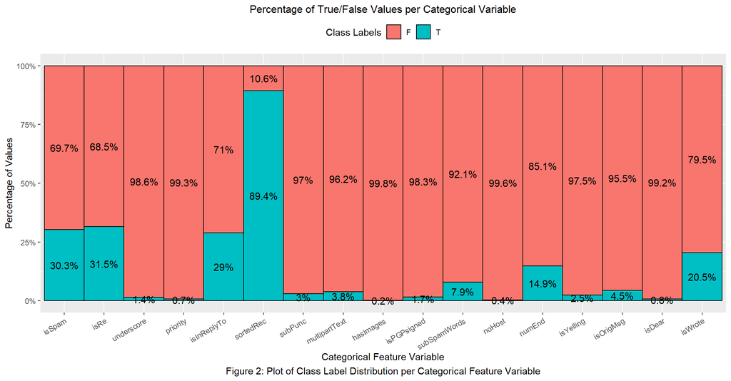

The following plot shown below in Figure 3 visualizes the distribution of data points for continuous feature variables in the processed emails data frame. These features have average values below 25 with roughly half the variables having average values around 0. The distribution of the “forwards”, “numRec”, “perCaps”, “perHTML”, and “subBlanks” variables also present long right tails; as can be seen with the accumulation of black dots extending past the box (75th percentile) and towards values of 100.

For the features listed in Figure 3, a potential outlier email is highlighted in red that presents with a value of 311 (index 5239) for the number of recipients (numRec). However, this outlier should not be considered as an error since intuition suggests that this email would most likely be spam due to an usually large number of intended recipients. A quick search for this outlier email verifies that it is a spam message, and further suggests that a higher number of recipients may be correlated with a spam email.

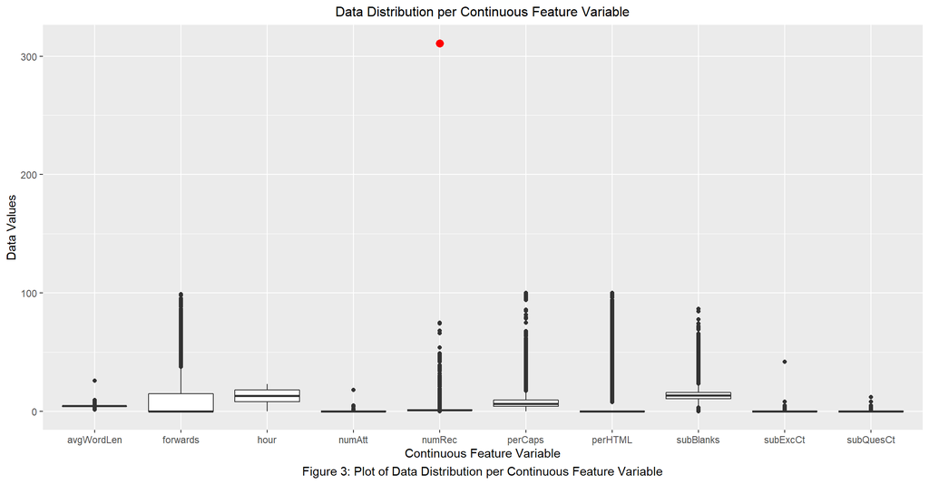

The last 3 continuous variables are visualized in a correlation matrix due to the longer right tails in their data distributions. The correlation matrix visualization (Figure 4) displays bivariate scatterplots with fitted lines on the bottom left, histograms of each variable along the diagnonal, and corresponding pearson’s correlation on the top right for the numLines, bodyChartCt, and numDlr features. The scales for the x and y axis are representative of that particular variable’s range of values. There appears to be outliers present in each of these variables with an email having 6319 lines for numLines, 188505 characters for bodyCharCt, and 1977 dollar signs for numDlr. These outlier values are highlighted in red in Figure 4 for easier visualization.

The outliers for numLines and bodyCharCt appear to come from the same emails (index 4193), but do not seem to be errors since their is no maximum text length restriction for emails sent. The large number of dollar signs indicates an outlier (index 3997) that does seem out of the ordinary, but may be context specific regarding finances. The decision on how to handle these outliers will be further examined when building the model and evaluating if its inclusion affects performance. Furthermore, this figure indicates an extremely high correlation between the numLines and bodyCharCt since both of these features are measurements of message length. The inclusion of both these variables will be further evaluated in model building to evaluate their effects on performance. Note: bodyCharCt seems to be a more informative measurement of message length.

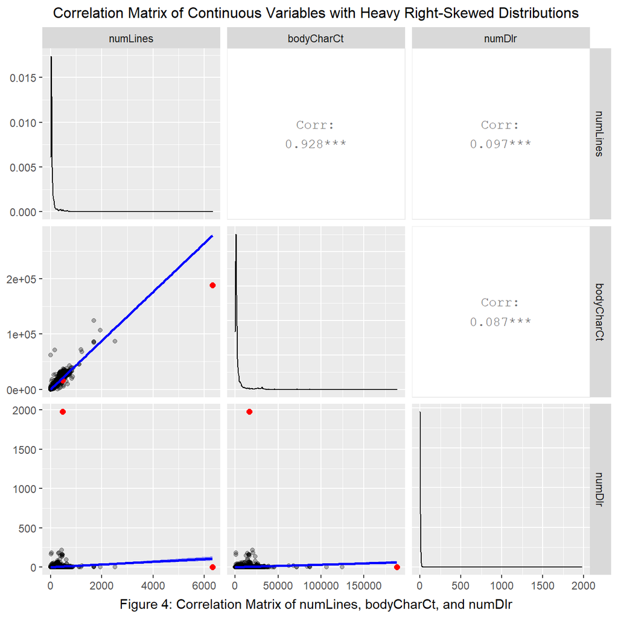

### Train-Test Split

The processed emails data frame is split into a training set that contains 70% of the emails and a test set that contains 30% of the emails with stratified sampling to preserve the class distributions of the target variable “isSpam”, meaning each data split will contain roughly 70% non-spam emails and 30% spam emails. The training set has 4341 observations and the test set has 1859 observations.

Following this split, the training and test splits also appear to maintain approximately the same levels of class distributions for the other categorical variables (plot shown in the Appendix) with only slight changes in the thousandth decimal place compared to Figure 2.

The training split will be used to tune hyperparameters in the classification tree model in a k-fold cross validation scheme while the test split will be saved to evaluate the performance of our final model.

### Impute Missing Values

The processed emails dataframe has 7 feature that contain missing values: subSpamWords has 4, noHost has 1, isYelling has 4, subExcCt has 16, subQuesCt has 16, and subBlanks has 16. The “numRec” feature has an overwhelmingly larger amount of missing values with 147, as highlighted below in red within Figure 5.

The imputation methods will be made based on only the training data split to prevent data leakage. The categorical variables [“subSpamWords”, “noHost”, “isYelling”] will be imputed via probability based on the distribution frequency of the class labels. The continuous variables will be imputed based on the average/median value of the data points within that respective feature.

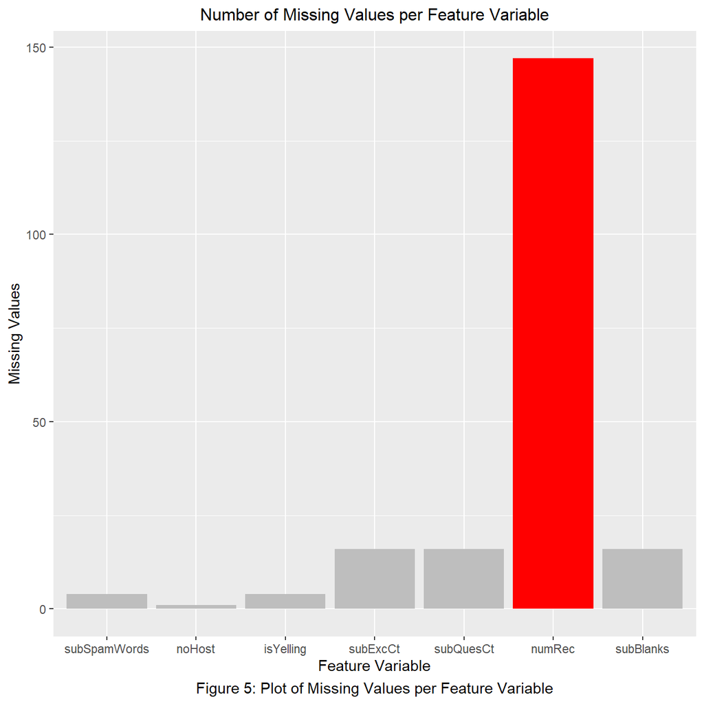

Since the “numRec” also indicates an integer value, the imputed mean value will be rounded to the nearest whole number. In cases where there is an outlier value present that skews the average value out of proportion, the decision to impute by median value is recommended as a more representative value of the data. Since the “subBlanks” feature is a measure of percentage, the mean value is chosen as the imputation method. The mean and median for this variable is roughly the same at about ~13-14%.

Summary statistics of the data splits following imputation can be examined in the Appendix verifying that missing values no longer exist in the data.

## Classification Tree-Based Model

The classification tree will be trained through recursive partitioning on the training data split. This approach builds a decision tree that aims to accurately label the emails by splitting into subpopulations of emails based on threshold values or labels of the independent explanatory variables in the data. The recursive process begins with all emails in the training data labeled according to the target variable (isSpam), a number of splits on different feature criterion will follow based on the inputted model hyperparameters.

### Hyperparameter Tuning

The following hyperparameters were tuned in the classification tree: complexity parameter (cp), the maximum depth of any node in the final tree (maxdepth), the minimum number of observations that must exist in a node for a split to occur (minsplit), and the number of observations in any terminal node (minbucket).

The complexity parameter influences computation time by pruning off splits that do not decrease the overall lack of fit by the cp value. The maximum depth is the length of the tree from root node to terminal node and controls for possible number of splits starting from the root node. The minsplit and minbucket parameters are related by restricting the minimum number of emails that must exist in a node. The difference is that the minsplit uses the parameter value to determine a potential split and minbucket uses the parameter value as a requirement size for a terminal node (bottom of tree).

Vectors of hyperparameter values to be tuned are performed in a grid search fashion to find the values that yield the misclassification rate in the tree. The grid search results are visualized in plots to easily locate optimal hyperparameter values (highlighted in red) that yield the lowest misclassification rate. The optimal values found were 0.002 for cp [Figure 6], 11 for max depth [Figure 7], 40 for min split [Figure 8], and 10 for minbucket [Figure 9]. A max depth of 11 was chosen since there appears to be diminishing returns in error minimization following that value. A minsplit value of 40 and minbucket value of 10 were chosen because they were the highest values that yielded the lowest error. This was done to prevent overcomplex models and promote more efficient computational times.

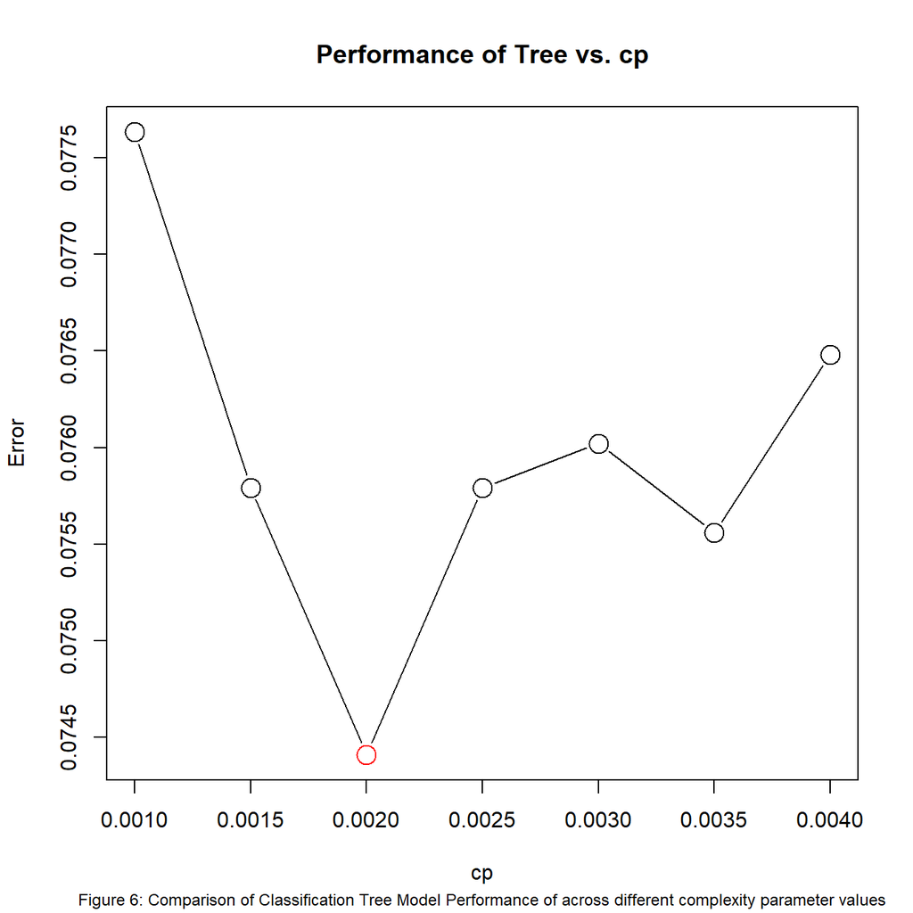

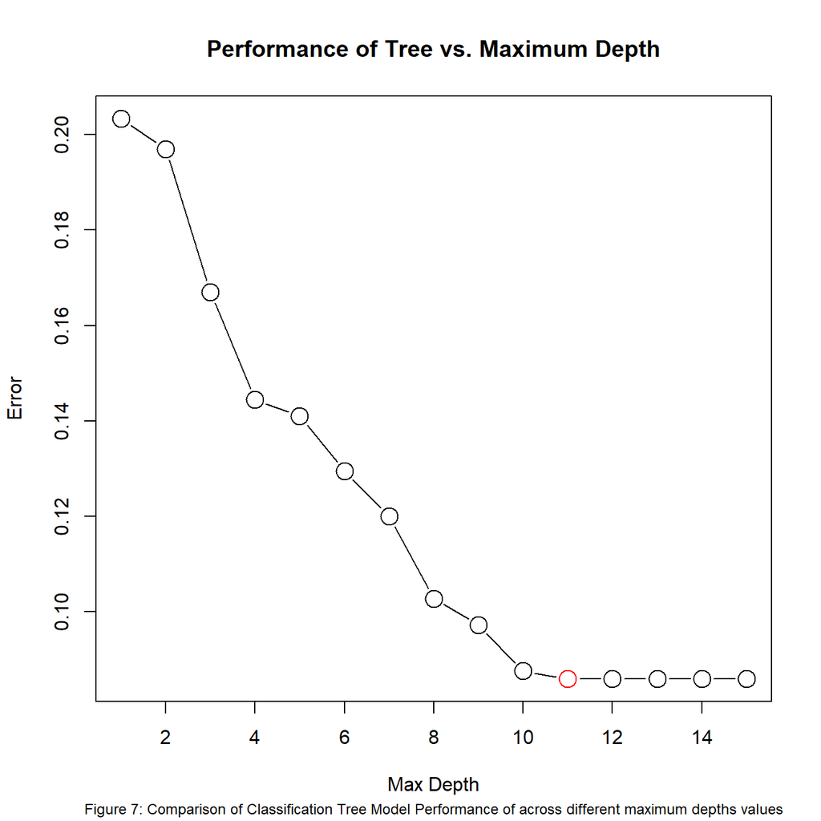

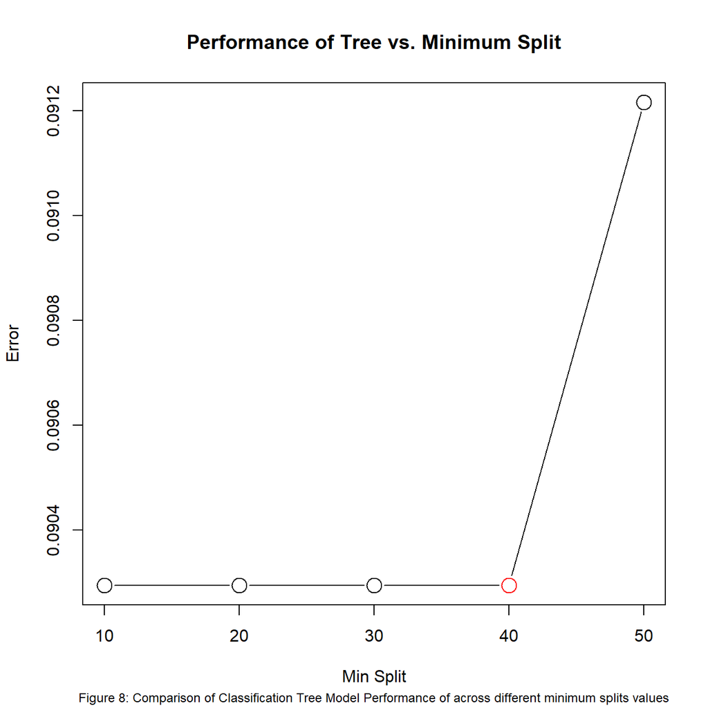

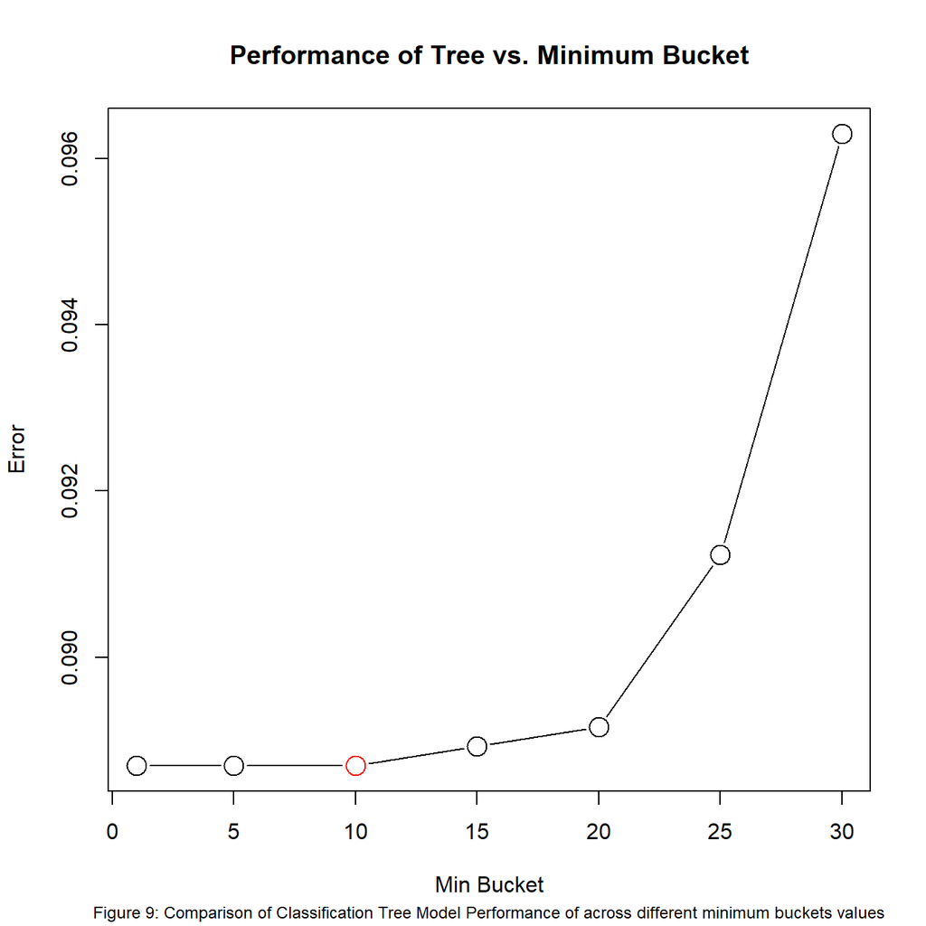

### Decision Tree from Recursive Partitioning

Note: The specific values referenced were extracted from the rpartFit1 model output provided in the Appendix under “Recursive Partitioning Decision Paths”.

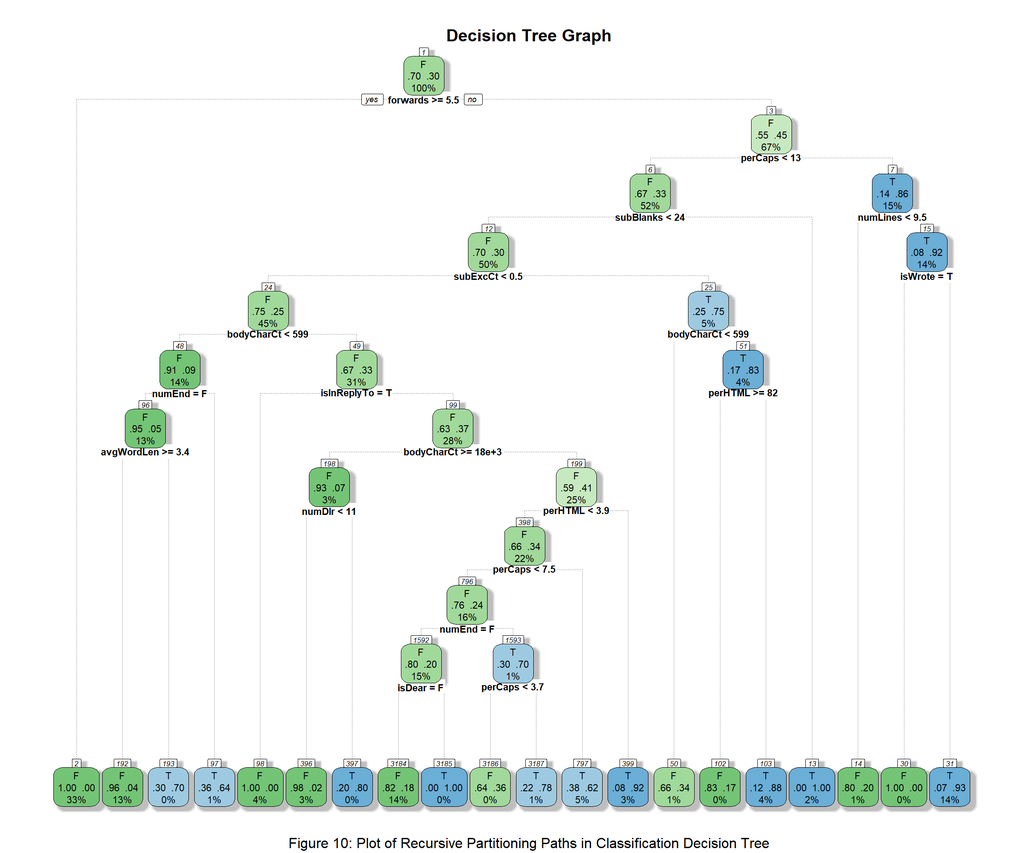

### Model Performance

#### Training Data

```
## Confusion Matrix and Statistics
##
##           Reference
## Prediction    F    T
##          F 2839  169
##          T  185 1148
##
##                Accuracy : 0.9185
##                  95% CI : (0.9099, 0.9264)
##     No Information Rate : 0.6966
##     P-Value [Acc > NIR] : <2e-16
##
##                   Kappa : 0.8077
##
##  Mcnemar's Test P-Value : 0.4253
##
##             Sensitivity : 0.8717
##             Specificity : 0.9388
##          Pos Pred Value : 0.8612
##          Neg Pred Value : 0.9438
##              Prevalence : 0.3034
##          Detection Rate : 0.2645
##    Detection Prevalence : 0.3071
##       Balanced Accuracy : 0.9053
##
##        'Positive' Class : T
##
```

#### Test Data

```
## Confusion Matrix and Statistics
##
##           Reference
## Prediction    F    T
##          F 1186   84
##          T  109  480
##
##                Accuracy : 0.8962
##                  95% CI : (0.8814, 0.9097)
##     No Information Rate : 0.6966
##     P-Value [Acc > NIR] : < 2e-16
##
##                   Kappa : 0.7574
##
##  Mcnemar's Test P-Value : 0.08407
##
##             Sensitivity : 0.8511
##             Specificity : 0.9158
##          Pos Pred Value : 0.8149
##          Neg Pred Value : 0.9339
##              Prevalence : 0.3034
##          Detection Rate : 0.2582
##    Detection Prevalence : 0.3168
##       Balanced Accuracy : 0.8834
##
##        'Positive' Class : T
##
```

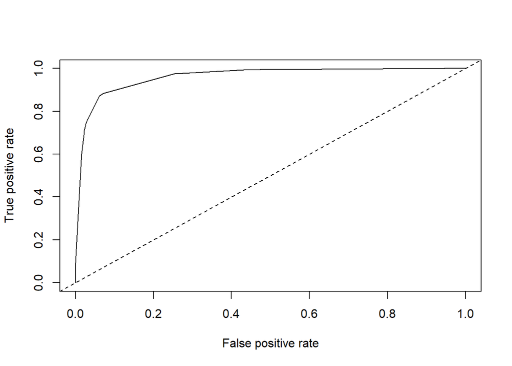

Confusion Matrix and Performance Metrics of Test Data

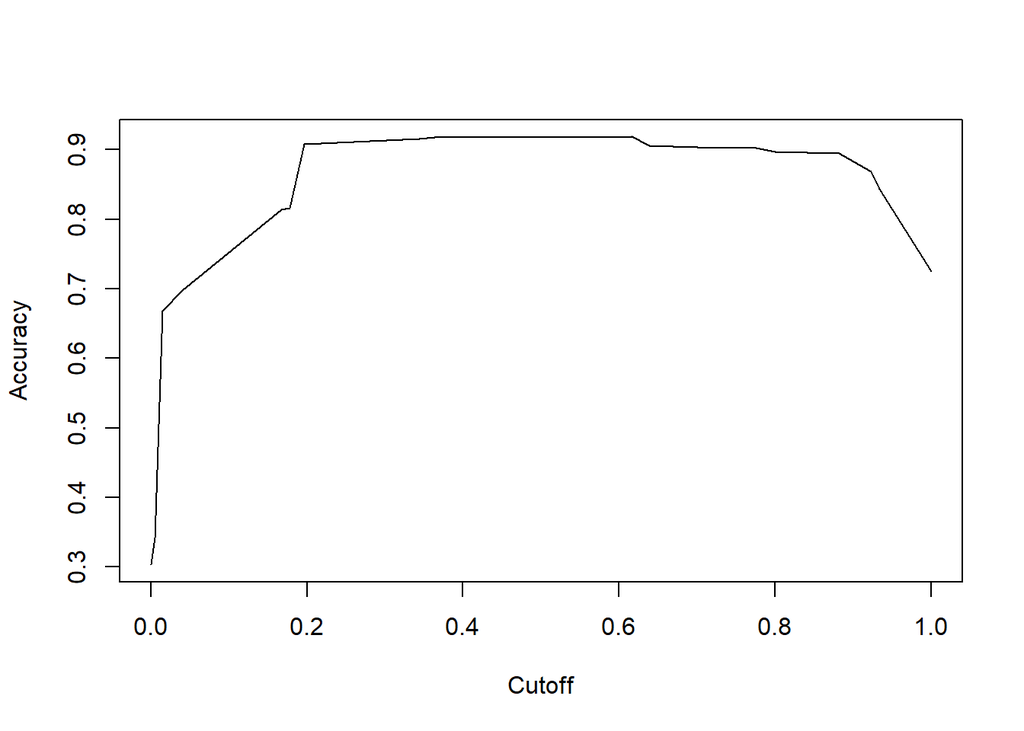

Confusion Matrix and Performance Metrics of Test Data

### Variable Importance

A plot to visualize the feature variable importances is provided below in Figure 11. The splits in the decision tree were performed on the information gain index which is a measure of reduction in entropy or uncertainty in the data. The classification tree model aims to reduce the entropy (a measure of impurity) in the target variable (isSpam) by splitting the emails into subpopulations. There is roughly 30% impurity in the isSpam target variable since the original strata noted in the EDA was 70% non-spam and 30% spam.

The decision tree splits these emails into partitions to reduce the impurity of the population based on the explanatory variables. The greater the reduction in this impurity following a split on an explanatory variable, the more information gained about the target variable from this explanatory variable. This provides a measure of which explanatory variables are the most useful in discriminating between classes of our target variable.

From the classification tree trained, the 3 most important features in discriminating between spam and non-spam emails are the number of forwards, the percentage of capitals among all letters in the message body (perCaps), and if âRe:â appears at the start of the subject (isRe). The information gain measure of these top 3 variables are colored below in green within Figure 11.

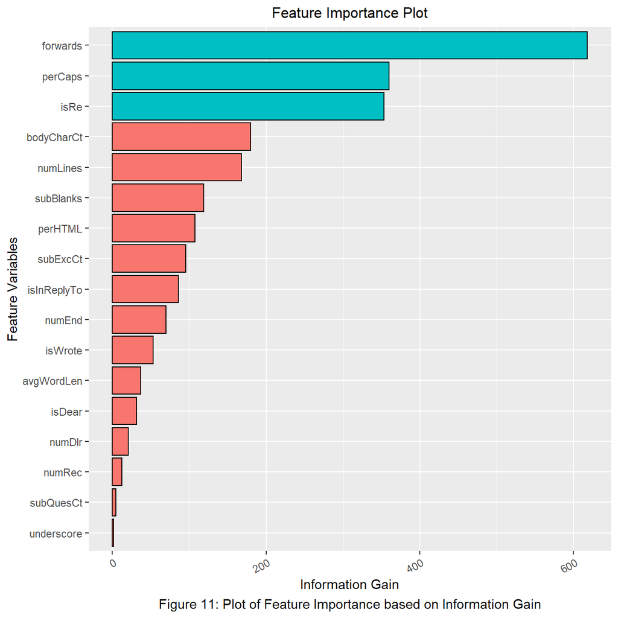

## Conclusion

The existing outliers were kept when training the classification tree model since they did not appear to be errors. The outlier for the numDlr variable was also kept since it was not an important feeature that heavily influenced differentiation between spam and non-spam emails. A separate model was also trained with the removal of the numLines variable, but did not show noticable improvements over the tree model with all variables included (provided in the Appendix). The decision was made to train the model using all features rather than exlcuding numLines.

The variables “forwards”, “perCaps”, and “isRe” provided the most information gain following a partition. However, it is interesting to note that the decision tree plotted did not have any partition splits on the “isRe” variable despite its large information gain value. The other two variables “forwards” and “perCaps” were shown to be important splits in the decision tree, occuring as the first two partition splits in the tree.

The classification tree generalized well to the test data with slightly lower performance than the training data and did not present with issues of overfitting. The classification accuracy of 89.6% indicates that the model has good overall performance with 85.1% sensitivity and 91.6% specificity. However, the model has a comparatively low precision (positive predictive value) of 81.5% as a result of fewer spam messages in the data compared to non-spam messages.

Suggestions to further improve this study are to employ a stratified k-fold cross validation scheme on the training data split to limit model bias since only a stratified train-test split was used in this analysis. Furthermore, an ensemble learning method such as random forests on classification trees could be implemented to improve model performance, particularly to address the lower precision metric. Additional trees in an ensemble model should aim to include the “isRe” feature since it was one of top 3 most important variables based on information gain.

### Appendix

Further exploratory data analysis can be examined in the tables and figures provided below to better understand the data and where specific values mentioned were extracted from.

#### Entire Processed Emails Data Frame

Summary Statistics of Numerical Variables (All Emails)

|  | numLines | bodyCharCt | subExcCt | subQuesCt | numAtt | numRec | perCaps | hour | perHTML | subBlanks | forwards | avgWordLen | numDlr |
| --- | --- | --- | --- | --- | --- | --- | --- | --- | --- | --- | --- | --- | --- |
| nbr.val | 6.200000e+03 | 6.200000e+03 | 6184.0000000 | 6184.0000000 | 6200.0000000 | 6.053000e+03 | 6.200000e+03 | 6.200000e+03 | 6.200000e+03 | 6.184000e+03 | 6.200000e+03 | 6.200000e+03 | 6.200000e+03 |
| nbr.null | 0.000000e+00 | 0.000000e+00 | 5558.0000000 | 5479.0000000 | 5820.0000000 | 7.300000e+01 | 6.000000e+00 | 2.000000e+02 | 5.239000e+03 | 1.440000e+02 | 3.687000e+03 | 0.000000e+00 | 4.916000e+03 |
| nbr.na | 0.000000e+00 | 0.000000e+00 | 16.0000000 | 16.0000000 | 0.0000000 | 1.470000e+02 | 0.000000e+00 | 0.000000e+00 | 0.000000e+00 | 1.600000e+01 | 0.000000e+00 | 0.000000e+00 | 0.000000e+00 |
| min | 2.000000e+00 | 6.000000e+00 | 0.0000000 | 0.0000000 | 0.0000000 | 0.000000e+00 | 0.000000e+00 | 0.000000e+00 | 0.000000e+00 | 0.000000e+00 | 0.000000e+00 | 1.363072e+00 | 0.000000e+00 |
| max | 6.319000e+03 | 1.885050e+05 | 42.0000000 | 12.0000000 | 18.0000000 | 3.110000e+02 | 1.000000e+02 | 2.300000e+01 | 1.000000e+02 | 8.641975e+01 | 9.905827e+01 | 2.600000e+01 | 1.977000e+03 |
| range | 6.317000e+03 | 1.884990e+05 | 42.0000000 | 12.0000000 | 18.0000000 | 3.110000e+02 | 1.000000e+02 | 2.300000e+01 | 1.000000e+02 | 8.641975e+01 | 9.905827e+01 | 2.463693e+01 | 1.977000e+03 |
| sum | 4.705420e+05 | 2.043678e+07 | 916.0000000 | 905.0000000 | 423.0000000 | 1.253100e+04 | 5.779409e+04 | 7.627900e+04 | 5.193254e+04 | 8.785553e+04 | 6.451422e+04 | 2.773891e+04 | 1.066900e+04 |
| median | 3.500000e+01 | 1.177500e+03 | 0.0000000 | 0.0000000 | 0.0000000 | 1.000000e+00 | 6.265060e+00 | 1.300000e+01 | 0.000000e+00 | 1.333333e+01 | 0.000000e+00 | 4.440825e+00 | 0.000000e+00 |
| mean | 7.589387e+01 | 3.296255e+03 | 0.1481242 | 0.1463454 | 0.0682258 | 2.070213e+00 | 9.321628e+00 | 1.230306e+01 | 8.376216e+00 | 1.420691e+01 | 1.040552e+01 | 4.474017e+00 | 1.720806e+00 |
| SE.mean | 1.917949e+00 | 9.097898e+01 | 0.0093327 | 0.0064821 | 0.0045456 | 7.752920e-02 | 1.284838e-01 | 8.548310e-02 | 2.733246e-01 | 1.006290e-01 | 2.335063e-01 | 7.493300e-03 | 3.371680e-01 |
| CI.mean.0.95 | 3.759845e+00 | 1.783503e+02 | 0.0182954 | 0.0127071 | 0.0089110 | 1.519848e-01 | 2.518729e-01 | 1.675765e-01 | 5.358110e-01 | 1.972678e-01 | 4.577532e-01 | 1.468950e-02 | 6.609662e-01 |
| var | 2.280688e+04 | 5.131848e+07 | 0.5386250 | 0.2598346 | 0.1281078 | 3.638321e+01 | 1.023502e+02 | 4.530562e+01 | 4.631793e+02 | 6.262034e+01 | 3.380561e+02 | 3.481265e-01 | 7.048301e+02 |
| std.dev | 1.510195e+02 | 7.163692e+03 | 0.7339107 | 0.5097397 | 0.3579216 | 6.031849e+00 | 1.011683e+01 | 6.730945e+00 | 2.152160e+01 | 7.913302e+00 | 1.838630e+01 | 5.900225e-01 | 2.654864e+01 |
| coef.var | 1.989877e+00 | 2.173282e+00 | 4.9546987 | 3.4831277 | 5.2461315 | 2.913637e+00 | 1.085307e+00 | 5.470950e-01 | 2.569370e+00 | 5.570038e-01 | 1.766976e+00 | 1.318776e-01 | 1.542802e+01 |

Summary Statistics of Categorical Variables (All Emails)

|  | isSpam | isRe | underscore | priority | isInReplyTo | sortedRec | subPunc | multipartText | hasImages | isPGPsigned | subSpamWords | noHost | numEnd | isYelling | isOrigMsg | isDear | isWrote |
| --- | --- | --- | --- | --- | --- | --- | --- | --- | --- | --- | --- | --- | --- | --- | --- | --- | --- |
|  | F:4319 | F:4246 | F:6111 | F:6157 | F:4404 | F: 659 | F:6013 | F:5964 | F:6186 | F:6097 | F :5705 | F :6175 | F:5279 | F :6043 | F:5924 | F:6151 | F:4931 |
|  | T:1881 | T:1954 | T: 89 | T: 43 | T:1796 | T:5541 | T: 187 | T: 236 | T: 14 | T: 103 | T : 491 | T : 24 | T: 921 | T : 153 | T: 276 | T: 49 | T:1269 |
|  | NA | NA | NA | NA | NA | NA | NA | NA | NA | NA | NA’s: 4 | NA’s: 1 | NA | NA’s: 4 | NA | NA | NA |

#### Training-Test Data Splits

Summary Statistics of Numerical Variables (Training Data)

|  | numLines | bodyCharCt | subExcCt | subQuesCt | numAtt | numRec | perCaps | hour | perHTML | subBlanks | forwards | avgWordLen | numDlr |
| --- | --- | --- | --- | --- | --- | --- | --- | --- | --- | --- | --- | --- | --- |
| nbr.val | 4.341000e+03 | 4.341000e+03 | 4341.0000000 | 4341.0000000 | 4341.0000000 | 4341.0000000 | 4.341000e+03 | 4.341000e+03 | 4.341000e+03 | 4.341000e+03 | 4.341000e+03 | 4.341000e+03 | 4341.0000000 |
| nbr.null | 0.000000e+00 | 0.000000e+00 | 3900.0000000 | 3838.0000000 | 4065.0000000 | 52.0000000 | 4.000000e+00 | 1.350000e+02 | 3.678000e+03 | 9.600000e+01 | 2.580000e+03 | 0.000000e+00 | 3428.0000000 |
| nbr.na | 0.000000e+00 | 0.000000e+00 | 0.0000000 | 0.0000000 | 0.0000000 | 0.0000000 | 0.000000e+00 | 0.000000e+00 | 0.000000e+00 | 0.000000e+00 | 0.000000e+00 | 0.000000e+00 | 0.0000000 |
| min | 2.000000e+00 | 6.000000e+00 | 0.0000000 | 0.0000000 | 0.0000000 | 0.0000000 | 0.000000e+00 | 0.000000e+00 | 0.000000e+00 | 0.000000e+00 | 0.000000e+00 | 1.363072e+00 | 0.0000000 |
| max | 6.319000e+03 | 1.885050e+05 | 42.0000000 | 12.0000000 | 5.0000000 | 311.0000000 | 1.000000e+02 | 2.300000e+01 | 1.000000e+02 | 8.461538e+01 | 9.905827e+01 | 9.038462e+00 | 1977.0000000 |
| range | 6.317000e+03 | 1.884990e+05 | 42.0000000 | 12.0000000 | 5.0000000 | 311.0000000 | 1.000000e+02 | 2.300000e+01 | 1.000000e+02 | 8.461538e+01 | 9.905827e+01 | 7.675390e+00 | 1977.0000000 |
| sum | 3.321730e+05 | 1.430069e+07 | 656.0000000 | 644.0000000 | 293.0000000 | 9161.0000000 | 4.061716e+04 | 5.332200e+04 | 3.577489e+04 | 6.166497e+04 | 4.494651e+04 | 1.939263e+04 | 8270.0000000 |
| median | 3.500000e+01 | 1.168000e+03 | 0.0000000 | 0.0000000 | 0.0000000 | 1.0000000 | 6.250000e+00 | 1.300000e+01 | 0.000000e+00 | 1.333333e+01 | 0.000000e+00 | 4.440559e+00 | 0.0000000 |
| mean | 7.651993e+01 | 3.294330e+03 | 0.1511173 | 0.1483529 | 0.0674960 | 2.1103432 | 9.356637e+00 | 1.228334e+01 | 8.241163e+00 | 1.420525e+01 | 1.035395e+01 | 4.467318e+00 | 1.9050910 |
| SE.mean | 2.468913e+00 | 1.127602e+02 | 0.0123185 | 0.0078955 | 0.0042308 | 0.0999885 | 1.552926e-01 | 1.018893e-01 | 3.237812e-01 | 1.189097e-01 | 2.788609e-01 | 7.936700e-03 | 0.4764168 |
| CI.mean.0.95 | 4.840331e+00 | 2.210676e+02 | 0.0241505 | 0.0154792 | 0.0082945 | 0.1960286 | 3.044528e-01 | 1.997551e-01 | 6.347765e-01 | 2.331237e-01 | 5.467098e-01 | 1.555990e-02 | 0.9340202 |
| var | 2.646071e+04 | 5.519524e+07 | 0.6587251 | 0.2706131 | 0.0777013 | 43.4000335 | 1.046866e+02 | 4.506578e+01 | 4.550855e+02 | 6.137961e+01 | 3.375709e+02 | 2.734428e-01 | 985.2896077 |
| std.dev | 1.626675e+02 | 7.429350e+03 | 0.8116188 | 0.5202048 | 0.2787495 | 6.5878702 | 1.023165e+01 | 6.713105e+00 | 2.133273e+01 | 7.834514e+00 | 1.837310e+01 | 5.229176e-01 | 31.3893231 |
| coef.var | 2.125818e+00 | 2.255193e+00 | 5.3707887 | 3.5065360 | 4.1298695 | 3.1217055 | 1.093518e+00 | 5.465209e-01 | 2.588559e+00 | 5.515226e-01 | 1.774501e+00 | 1.170540e-01 | 16.4765480 |

Summary Statistics of Categorical Variables (Training Data)

|  | isSpam | isRe | underscore | priority | isInReplyTo | sortedRec | subPunc | multipartText | hasImages | isPGPsigned | subSpamWords | noHost | numEnd | isYelling | isOrigMsg | isDear | isWrote |
| --- | --- | --- | --- | --- | --- | --- | --- | --- | --- | --- | --- | --- | --- | --- | --- | --- | --- |
|  | F:3024 | F:2958 | F:4280 | F:4313 | F:3087 | F: 467 | F:4216 | F:4166 | F:4330 | F:4269 | F:3982 | F:4321 | F:3696 | F:4231 | F:4161 | F:4304 | F:3450 |
|  | T:1317 | T:1383 | T: 61 | T: 28 | T:1254 | T:3874 | T: 125 | T: 175 | T: 11 | T: 72 | T: 359 | T: 20 | T: 645 | T: 110 | T: 180 | T: 37 | T: 891 |

Summary Statistics of Numerical Variables (Test Data)

|  | numLines | bodyCharCt | subExcCt | subQuesCt | numAtt | numRec | perCaps | hour | perHTML | subBlanks | forwards | avgWordLen | numDlr |
| --- | --- | --- | --- | --- | --- | --- | --- | --- | --- | --- | --- | --- | --- |
| nbr.val | 1.859000e+03 | 1.859000e+03 | 1859.0000000 | 1859.0000000 | 1859.0000000 | 1859.0000000 | 1.859000e+03 | 1.859000e+03 | 1.859000e+03 | 1.859000e+03 | 1.859000e+03 | 1859.0000000 | 1859.0000000 |
| nbr.null | 0.000000e+00 | 0.000000e+00 | 1674.0000000 | 1657.0000000 | 1755.0000000 | 21.0000000 | 2.000000e+00 | 6.500000e+01 | 1.561000e+03 | 4.800000e+01 | 1.107000e+03 | 0.0000000 | 1488.0000000 |
| nbr.na | 0.000000e+00 | 0.000000e+00 | 0.0000000 | 0.0000000 | 0.0000000 | 0.0000000 | 0.000000e+00 | 0.000000e+00 | 0.000000e+00 | 0.000000e+00 | 0.000000e+00 | 0.0000000 | 0.0000000 |
| min | 2.000000e+00 | 2.700000e+01 | 0.0000000 | 0.0000000 | 0.0000000 | 0.0000000 | 0.000000e+00 | 0.000000e+00 | 0.000000e+00 | 0.000000e+00 | 0.000000e+00 | 1.3758621 | 0.0000000 |
| max | 1.699000e+03 | 8.633600e+04 | 5.0000000 | 4.0000000 | 18.0000000 | 66.0000000 | 9.802283e+01 | 2.300000e+01 | 9.824478e+01 | 8.641975e+01 | 9.905827e+01 | 26.0000000 | 180.0000000 |
| range | 1.697000e+03 | 8.630900e+04 | 5.0000000 | 4.0000000 | 18.0000000 | 66.0000000 | 9.802283e+01 | 2.300000e+01 | 9.824478e+01 | 8.641975e+01 | 9.905827e+01 | 24.6241379 | 180.0000000 |
| sum | 1.383690e+05 | 6.136093e+06 | 260.0000000 | 261.0000000 | 130.0000000 | 3664.0000000 | 1.717693e+04 | 2.295700e+04 | 1.615765e+04 | 2.641784e+04 | 1.956771e+04 | 8346.2794942 | 2399.0000000 |
| median | 3.500000e+01 | 1.194000e+03 | 0.0000000 | 0.0000000 | 0.0000000 | 1.0000000 | 6.279435e+00 | 1.300000e+01 | 0.000000e+00 | 1.351351e+01 | 0.000000e+00 | 4.4427861 | 0.0000000 |
| mean | 7.443195e+01 | 3.300749e+03 | 0.1398601 | 0.1403981 | 0.0699301 | 1.9709521 | 9.239878e+00 | 1.234911e+01 | 8.691581e+00 | 1.421078e+01 | 1.052593e+01 | 4.4896608 | 1.2904788 |
| SE.mean | 2.771689e+00 | 1.508281e+02 | 0.0116853 | 0.0111881 | 0.0115014 | 0.0959671 | 2.283535e-01 | 1.571108e-01 | 5.092963e-01 | 1.870080e-01 | 4.272525e-01 | 0.0167636 | 0.1637295 |
| CI.mean.0.95 | 5.435952e+00 | 2.958103e+02 | 0.0229178 | 0.0219427 | 0.0225571 | 0.1882146 | 4.478564e-01 | 3.081323e-01 | 9.988530e-01 | 3.667679e-01 | 8.379453e-01 | 0.0328775 | 0.3211130 |
| var | 1.428132e+04 | 4.229058e+07 | 0.2538409 | 0.2326997 | 0.2459145 | 17.1207919 | 9.693814e+01 | 4.588720e+01 | 4.821924e+02 | 6.501293e+01 | 3.393505e+02 | 0.5224138 | 49.8348447 |
| std.dev | 1.195045e+02 | 6.503121e+03 | 0.5038262 | 0.4823896 | 0.4958976 | 4.1377279 | 9.845717e+00 | 6.774010e+00 | 2.195888e+01 | 8.063060e+00 | 1.842147e+01 | 0.7227820 | 7.0593799 |
| coef.var | 1.605554e+00 | 1.970195e+00 | 3.6023576 | 3.4358708 | 7.0913363 | 2.0993548 | 1.065568e+00 | 5.485422e-01 | 2.526454e+00 | 5.673905e-01 | 1.750103e+00 | 0.1609881 | 5.4703573 |

Summary Statistics of Categorical Variables (Test Data)

|  | isSpam | isRe | underscore | priority | isInReplyTo | sortedRec | subPunc | multipartText | hasImages | isPGPsigned | subSpamWords | noHost | numEnd | isYelling | isOrigMsg | isDear | isWrote |
| --- | --- | --- | --- | --- | --- | --- | --- | --- | --- | --- | --- | --- | --- | --- | --- | --- | --- |
|  | F:1295 | F:1288 | F:1831 | F:1844 | F:1317 | F: 192 | F:1797 | F:1798 | F:1856 | F:1828 | F:1725 | F:1854 | F:1583 | F:1813 | F:1763 | F:1847 | F:1481 |
|  | T: 564 | T: 571 | T: 28 | T: 15 | T: 542 | T:1667 | T: 62 | T: 61 | T: 3 | T: 31 | T: 134 | T: 5 | T: 276 | T: 46 | T: 96 | T: 12 | T: 378 |

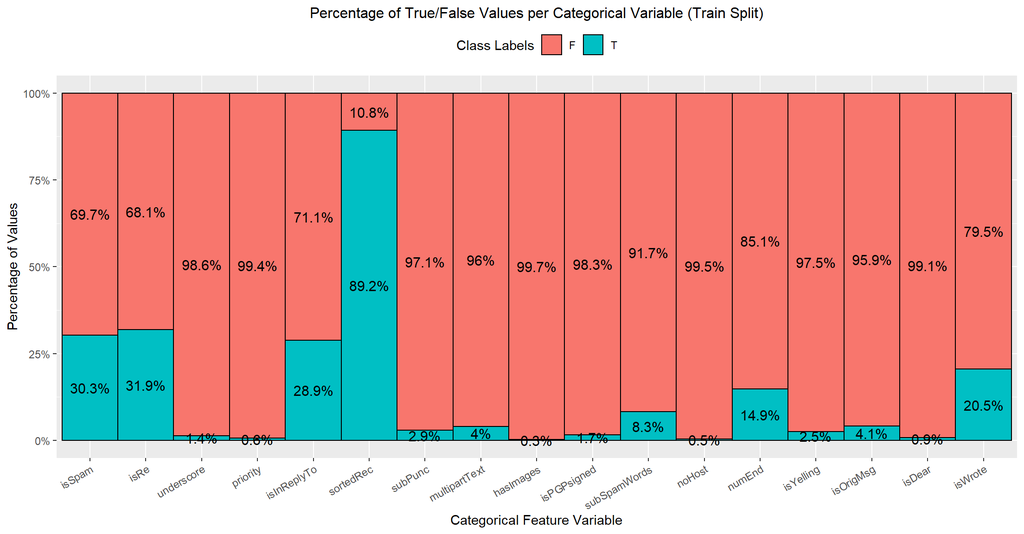

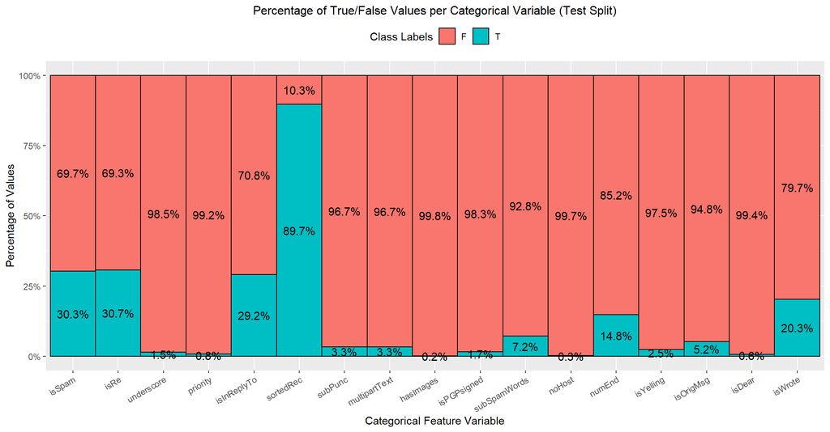

#### Recursive Partitioning Decision Paths of Classification Tree-Based Model

```
## n= 4341
##
## node), split, n, loss, yval, (yprob)
##       * denotes terminal node
##
##    1) root 4341 1317 F (0.696613683 0.303386317)
##      2) forwards>=5.513008 1432    7 F (0.995111732 0.004888268) *
##      3) forwards< 5.513008 2909 1310 F (0.549673427 0.450326573)
##        6) perCaps< 12.86925 2254  747 F (0.668589175 0.331410825)
##         12) subBlanks< 23.66947 2151  644 F (0.700604370 0.299395630)
##           24) subExcCt< 0.5 1954  496 F (0.746161720 0.253838280)
##             48) bodyCharCt< 598.5 594   52 F (0.912457912 0.087542088)
##               96) numEnd=F 558   29 F (0.948028674 0.051971326)
##                192) avgWordLen>=3.412766 548   22 F (0.959854015 0.040145985) *
##                193) avgWordLen< 3.412766 10    3 T (0.300000000 0.700000000) *
##               97) numEnd=T 36   13 T (0.361111111 0.638888889) *
##             49) bodyCharCt>=598.5 1360  444 F (0.673529412 0.326470588)
##               98) isInReplyTo=T 153    0 F (1.000000000 0.000000000) *
##               99) isInReplyTo=F 1207  444 F (0.632145816 0.367854184)
##                198) bodyCharCt>=18359 142   10 F (0.929577465 0.070422535)
##                  396) numDlr< 11 132    2 F (0.984848485 0.015151515) *
##                  397) numDlr>=11 10    2 T (0.200000000 0.800000000) *
##                199) bodyCharCt< 18359 1065  434 F (0.592488263 0.407511737)
##                  398) perHTML< 3.926441 936  315 F (0.663461538 0.336538462)
##                    796) perCaps< 7.548391 704  172 F (0.755681818 0.244318182)
##                     1592) numEnd=F 644  130 F (0.798136646 0.201863354)
##                       3184) isDear=F 625  111 F (0.822400000 0.177600000) *
##                       3185) isDear=T 19    0 T (0.000000000 1.000000000) *
##                     1593) numEnd=T 60   18 T (0.300000000 0.700000000)
##                       3186) perCaps< 3.69562 11    4 F (0.636363636 0.363636364) *
##                       3187) perCaps>=3.69562 49   11 T (0.224489796 0.775510204) *
##                    797) perCaps>=7.548391 232   89 T (0.383620690 0.616379310) *
##                  399) perHTML>=3.926441 129   10 T (0.077519380 0.922480620) *
##           25) subExcCt>=0.5 197   49 T (0.248730964 0.751269036)
##             50) bodyCharCt< 599 32   11 F (0.656250000 0.343750000) *
##             51) bodyCharCt>=599 165   28 T (0.169696970 0.830303030)
##              102) perHTML>=82.10844 12    2 F (0.833333333 0.166666667) *
##              103) perHTML< 82.10844 153   18 T (0.117647059 0.882352941) *
##         13) subBlanks>=23.66947 103    0 T (0.000000000 1.000000000) *
##        7) perCaps>=12.86925 655   92 T (0.140458015 0.859541985)
##         14) numLines< 9.5 51   10 F (0.803921569 0.196078431) *
##         15) numLines>=9.5 604   51 T (0.084437086 0.915562914)
##           30) isWrote=T 12    0 F (1.000000000 0.000000000) *
##           31) isWrote=F 592   39 T (0.065878378 0.934121622) *
```

#### Exclusion of numLines

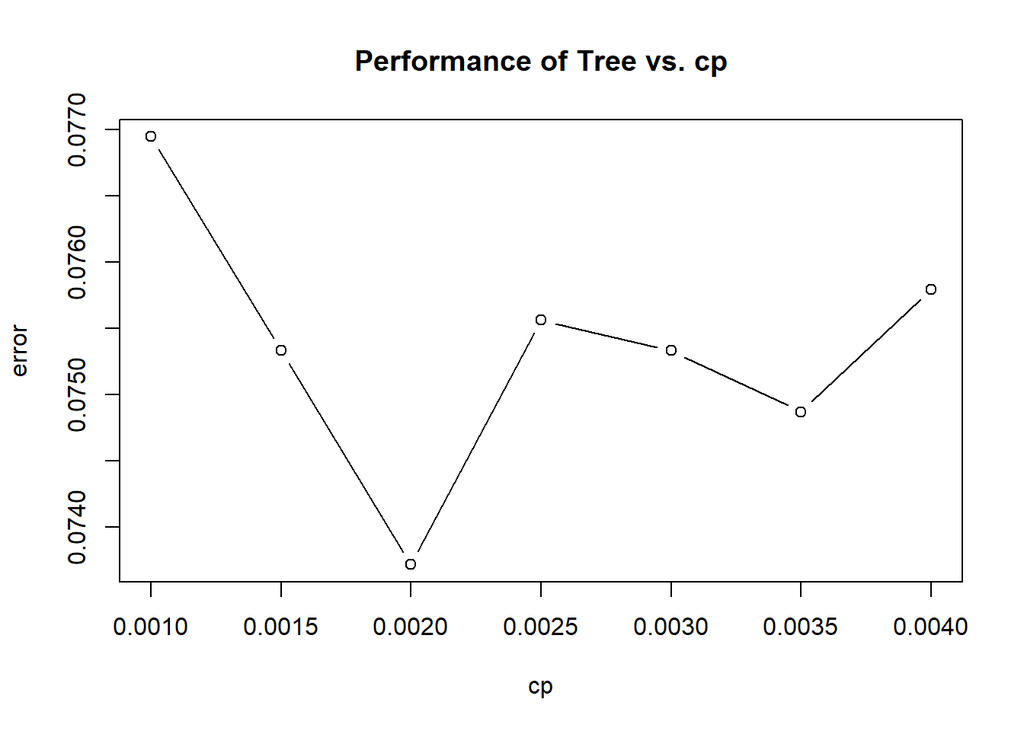

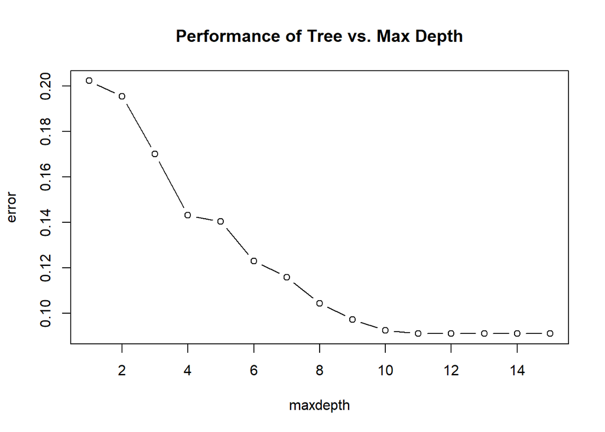

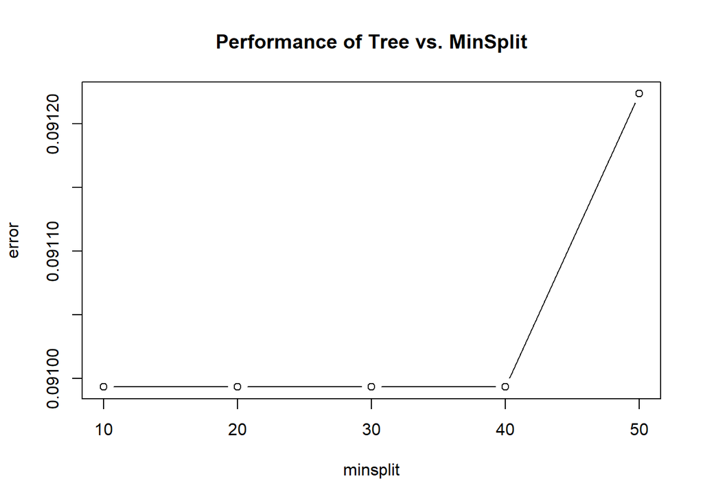

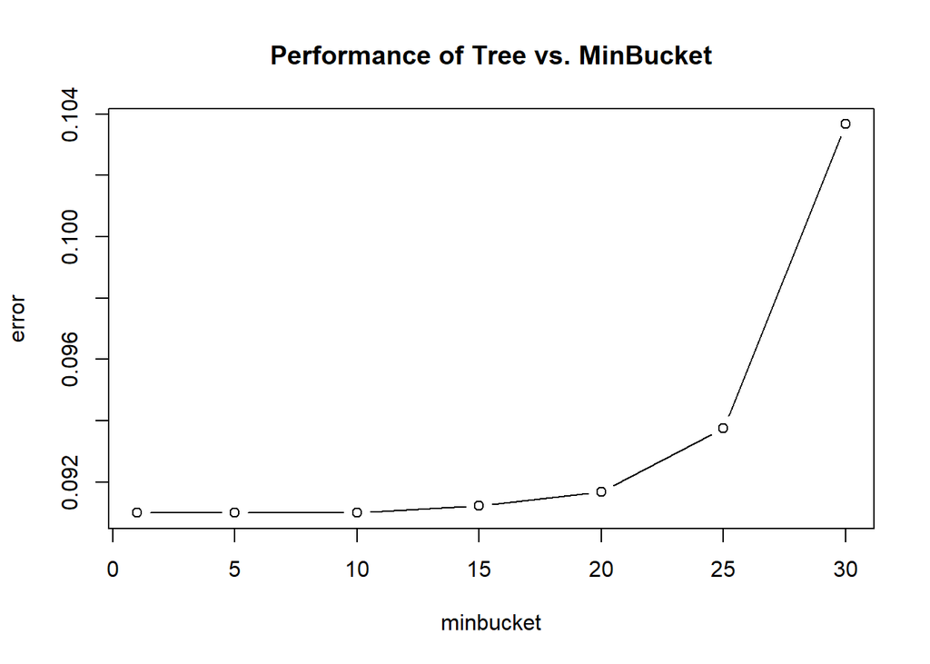

```
## Confusion Matrix and Statistics
##
##           Reference
## Prediction    F    T
##          F 2839  169
##          T  185 1148
##
##                Accuracy : 0.9185
##                  95% CI : (0.9099, 0.9264)
##     No Information Rate : 0.6966
##     P-Value [Acc > NIR] : <2e-16
##
##                   Kappa : 0.8077
##
##  Mcnemar's Test P-Value : 0.4253
##
##             Sensitivity : 0.8717
##             Specificity : 0.9388
##          Pos Pred Value : 0.8612
##          Neg Pred Value : 0.9438
##              Prevalence : 0.3034
##          Detection Rate : 0.2645
##    Detection Prevalence : 0.3071
##       Balanced Accuracy : 0.9053
##
##        'Positive' Class : T
##
```

```
## Confusion Matrix and Statistics
##
##           Reference
## Prediction    F    T
##          F 1184   84
##          T  111  480
##
##                Accuracy : 0.8951
##                  95% CI : (0.8803, 0.9087)
##     No Information Rate : 0.6966
##     P-Value [Acc > NIR] : < 2e-16
##
##                   Kappa : 0.7551
##
##  Mcnemar's Test P-Value : 0.06262
##
##             Sensitivity : 0.8511
##             Specificity : 0.9143
##          Pos Pred Value : 0.8122
##          Neg Pred Value : 0.9338
##              Prevalence : 0.3034
##          Detection Rate : 0.2582
##    Detection Prevalence : 0.3179
##       Balanced Accuracy : 0.8827
##
##        'Positive' Class : T
##
```